# Box Office Performance

Arjun Bingly, Caroline Krall, Nayaeun Kwon, Tara Thomas

2022-10-23

# 1. Introduction

Movies have always been a popular form of entertainment, but what makes a movie successful? The literature states multiple different factors that can influence box office sales. Most revolve around Oscar nominations, specific genres, and the directors/actors’ popularity (Scott 2022). One less researched avenue in the literature was rating reviews. The information that was publicly available for use led us to utilize datasets from IMDB and Rotten Tomatoes, very popular movie rating websites. The datasets from these sites will allow analysis in the ratings review space.

# 2. Description of the Data

We combined three different datasets, IMDB, Rotten Tomatoes, and Box Office Mojo to create our master dataset to answer the SMART question: What factors affect box office performance sales in the US? The IMDB dataset is publicly available online, the Rotten Tomato dataset was pulled from Kaggle, and the Box Office Mojo dataset was obtained from Data World.

```
## 'data.frame':    7981 obs. of  9 variables:
##  $ Title        : chr  "Please Give" "Dark Water" "The Accused" "The Lost City" ...
##  $ LifetimeGross: int  4033574 25473352 32078318 2484186 49981 929233 849915 132261 44544 1008404 ...
##  $ contentR     : Factor w/ 6 levels "G","PG","PG-13",..: 4 3 4 4 2 4 1 1 4 4 ...
##  $ Year         : int  2010 2005 1988 2006 2005 2004 1986 2005 1997 1991 ...
##  $ Runtime      : num  87 92 101 300 86 87 130 NA 103 85 ...
##  $ imdbR        : num  6.6 5.1 6.8 3.6 7 5.3 7.1 2.9 7 5.6 ...
##  $ rottentmtR   : int  87 80 91 25 4 69 80 67 80 0 ...
##  $ imdbC        : int  11359 199 960 32 89 46 1239 101 655 3884 ...
##  $ rottentmtC   : int  142 15 22 83 24 124 5 52 5 6 ...
##  - attr(*, "na.action")= 'omit' Named int [1:6] 348 1330 2694 2900 4102 5352
##   ..- attr(*, "names")= chr [1:6] "348" "1330" "2694" "2900" ...
```

Our refined `movie` dataset is organized 7981 observations and 9 variables (See above for a readout of the dataset’s structure).

Variable descriptions are as follows: *format :* **col name** - *description*

1. **Title** - The title of the movie. *(source: IMDB)*
2. **LifetimeGross** - The domestic lifetime gross of the movie in USD (not accounting inflation). *(source: Box Office Mojo)*
3. **contentR** - The category based on the movie suitability for audience. *(source: Rotten Tomatoes)*
4. **Year** - The year of movie release. *(source: IMDB)*
5. **Runtime** - The movie run time in minutes. *(source: IMDB)*
6. **imdbR** - The IMDB rating from 1 to 10, average of user votes. *(source: IMDB)*
7. **rottentmtR** - The percentage of positive critic reviews from 1 to 100. *(source: Rotten Tomatoes)*
8. **imdbC** - The number of votes that went into the IMDB rating. *(source: IMDB)*
9. **rottentmtC** - The number of critic ratings counted for tomatometer rating. *(source: Rotten Tomatoes)*

# 3. Variable EDA: Slicing the Data for an Overview

The dataset yields following observations for the `LifetimeGross` of ranked movies: while the minimum price is $72, the maximum price is $857,190,335 (fairly wide range); the mean is $28,050,244 (indicating mean is higher than median, $6,217,849, which means the shape of distribution is right-skewed as further indicated by the histogram below); the standard deviation is $55,544,311.

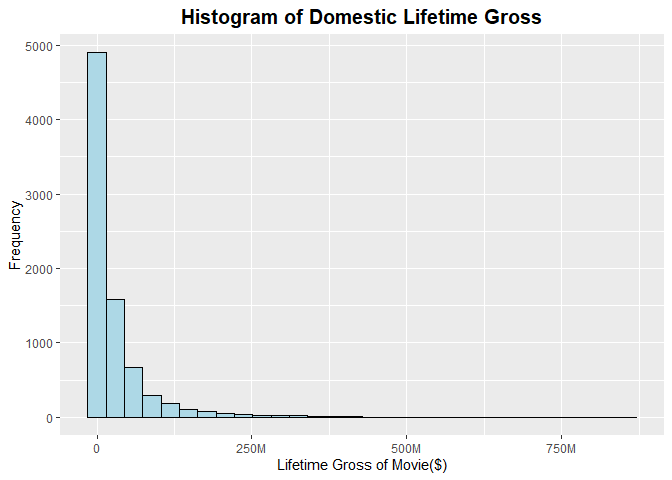

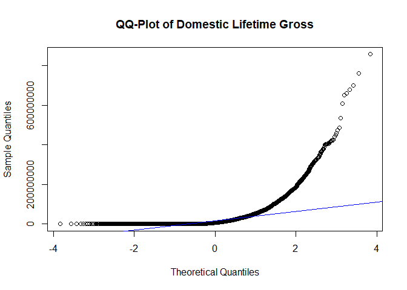

Most movies earned below $250M, but some movies that have a particularly high earning is lengthening their right tail. The following readout provide to figure out if any of the variables are highly correlated with high earning.

Below we have some plots for each dependent variables. Upon examining graphs, `contentR` negatively correlated with earning, `LifetimeGross` is even declined over time (`Year`) (Shown the third graph), the higher `imdbR`, the higher the earning, `rottentmtR` is not only that there is no difference in earning, but even that tends to decline, on `imdbC`, 75 percent of the movies are below `3rd Qutile` (indicating highly right-skwed), on `rottentmtC`, most movies are below `200`.

#### 3.2.1 **Conetent rating** overview

The descriptions for content rating we are dealing with are as follows: *format :* **Content rating** - *description*

1. **G** - For all audience. *(source: IMDB)*
2. **PG** - Parental guidance suggested (mainly for under 10’s). *(source: IMDB)*
3. **PG-13** - Parental guidance suggested for children under 13. *(source: IMDB)*
4. **R** - Under 17 not admitted without parent or guardian. *(source: IMDB)*
5. **NC17** - Under 17 not admitted. *(source: IMDB)*
6. **NR** - Not been submitted for a rating or an uncut version of movie. *(source: ATLAS CINEMAS)*

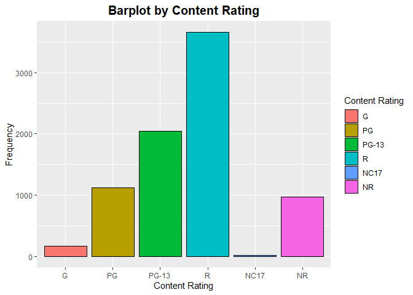

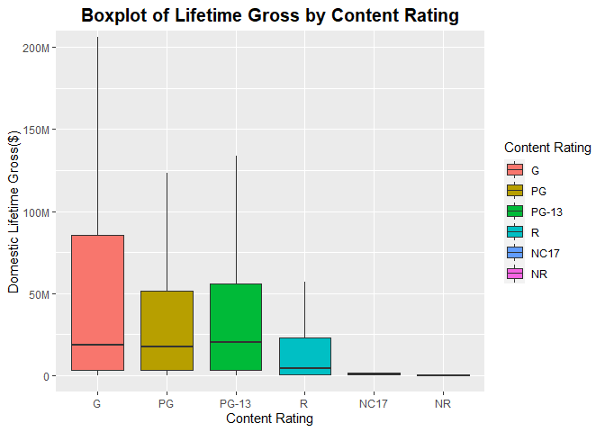

#### 3.2.2 **Year** overview

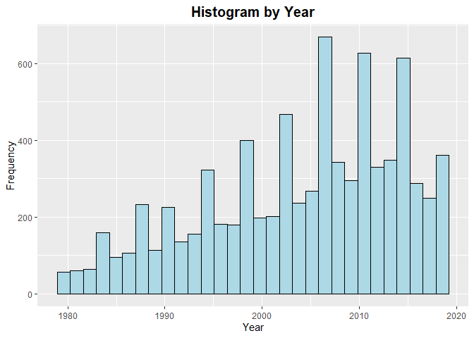

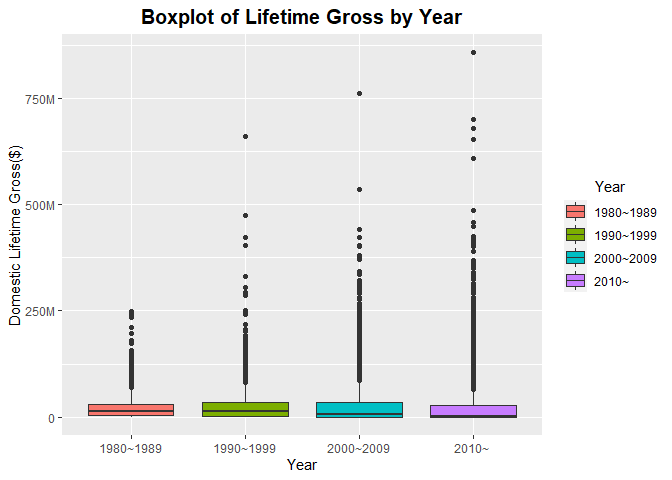

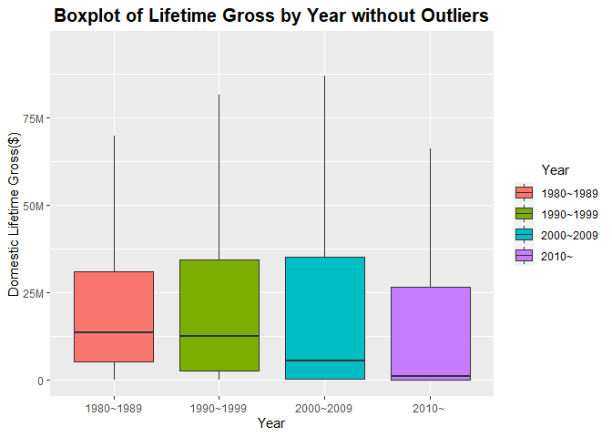

Over time, the movie industry grows, and the movies that consumers can choose from have diversified and increased. Regardless of the development of the movie industry, the movie earnings over time have a reducing tendency than before except for the top few that generated extremely high earnings, which are outliers.

#### 3.2.3 **IMDB rating** overview

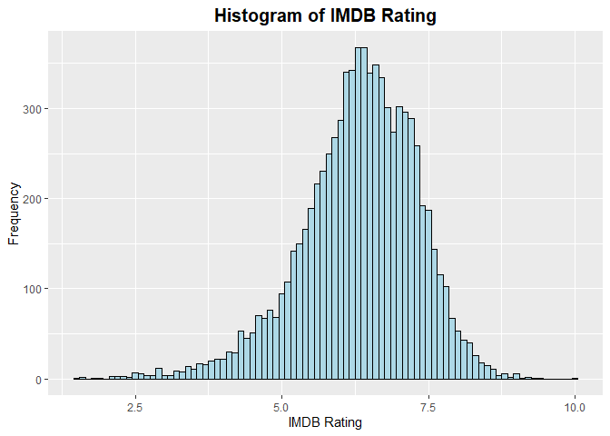

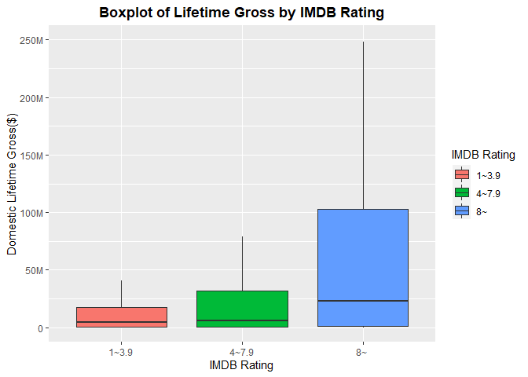

#### 3.2.4 **Rotten Tomatoes rating** overview

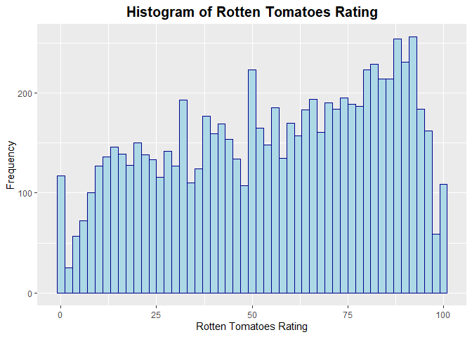

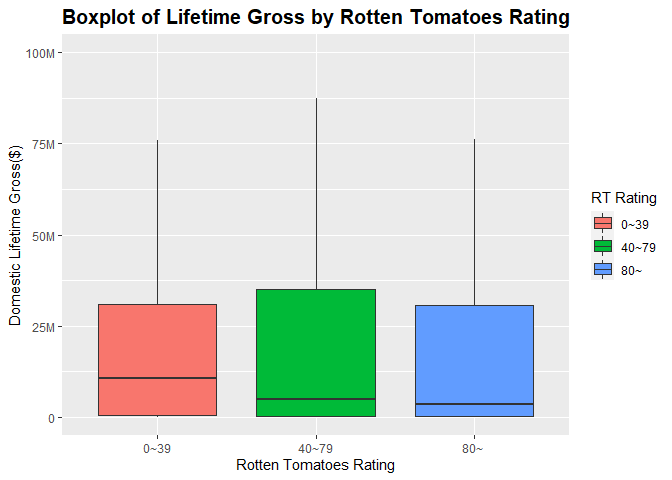

Unlike `imdbR`, `rottentmtR` represents an expert critique score. Good ratings from professionals do not necessarily guarantee high earnings because the public who has influence on movie earning tends to think that high cinematic quality movies are esoteric and convoluted.

#### 3.2.5 **IMDB count** overview

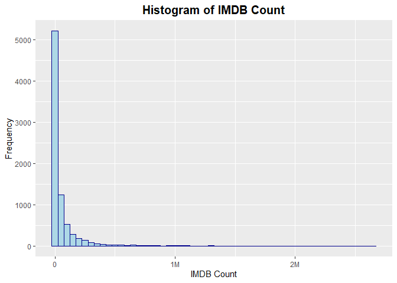

#### 3.2.6 **Rotten Tomatoes count** overview

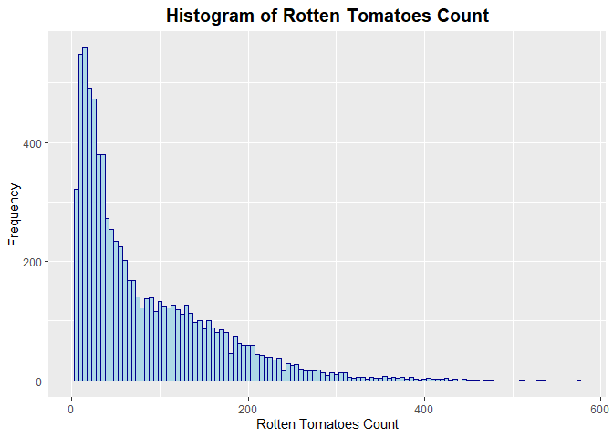

# 4. Variables EDA: Finding out Correlation

Now that we have investigated slices of the data, we can delve deeper with correlation test.

### 4.1 SMART Question: Does **rating** affect to box office performance?

#### 4.1.1 Correlation Test: **IMDB Rating**

From the scatterplot and correlation test for `imdbR`, it’s apparent that there is no strong correlation between `imdbR` and `LifetimeGross` with not meaningful value, 0.1407482. The p-value, however, is smaller than 0.05, so it has correlation but very slightly.

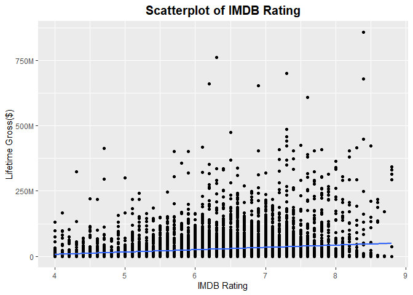

```
##
##  Pearson's product-moment correlation
##
## data:  nooutlierR$imdbR and nooutlierR$LifetimeGross
## t = 12.548, df = 7791, p-value < 0.00000000000000022
## alternative hypothesis: true correlation is not equal to 0
## 95 percent confidence interval:
##  0.1189170 0.1624434
## sample estimates:
##       cor
## 0.1407482
```

Now, let’s take a look at the same data for a hypothesis test; for the test, we did subset for rating by 3 groups (1 to 3.9, 4 to 7.9, 8 to 10) like 3.2.3 section, `imdbR`’s overview. But after removing outliers, several low rating was considered of outliers and converted to NA value, so there is no value on low group. We compared middle and high group.

```
##
##  Welch Two Sample t-test
##
## data:  midimdbR$imdbR and highimdbR$imdbR
## t = -109.65, df = 446.67, p-value < 0.00000000000000022
## alternative hypothesis: true difference in means is not equal to 0
## 95 percent confidence interval:
##  -1.933767 -1.865667
## sample estimates:
## mean of x mean of y
##  6.327135  8.226852
```

The mean for middle and high rating groups are 6.327135, 8.226852 respectively. The p-value for these two groups is 0, thus rejected the null that these two groups are the same.

#### 4.1.2 Correlation Test: **Rotten Tomatoes Rating**

As for `RottentmtR`, it exhibits similar behavior as `imdbR` data as well. It is even more clear that there is no strong correlation between `rottentmtR` and `LifetimeGross` with not meaningful value, 0.0793277.

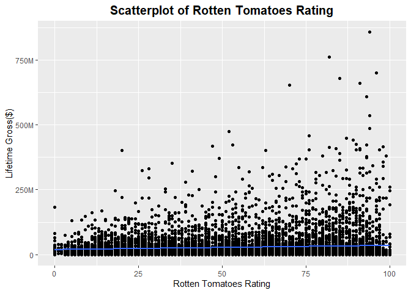

```
##
##  Pearson's product-moment correlation
##
## data:  nooutlierR$rottentmtR and nooutlierR$LifetimeGross
## t = 7.1084, df = 7979, p-value = 0.000000000001276
## alternative hypothesis: true correlation is not equal to 0
## 95 percent confidence interval:
##  0.05748804 0.10109151
## sample estimates:
##        cor
## 0.07932772
```

Similarly with `imdbR`, let’s look at a hypothesis test; for the test, we did subset for rating by 3 groups (0 to 39, 40 to 79, 80 to 100) like 3.2.4 section, `rottentmtR`’s overview.

```
##
##  Welch Two Sample t-test
##
## data:  lowrtR$rottentmtR and midrtR$rottentmtR
## t = -157.95, df = 6920.4, p-value < 0.00000000000000022
## alternative hypothesis: true difference in means is not equal to 0
## 95 percent confidence interval:
##  -50.84730 -49.60063
## sample estimates:
## mean of x mean of y
##  21.23045  71.45441
```

```
##
##  Welch Two Sample t-test
##
## data:  midrtR$rottentmtR and highrtR$rottentmtR
## t = -67.547, df = 7468.7, p-value < 0.00000000000000022
## alternative hypothesis: true difference in means is not equal to 0
## 95 percent confidence interval:
##  -18.15166 -17.12781
## sample estimates:
## mean of x mean of y
##  71.45441  89.09415
```

The mean for low and middle rating groups are 21.23045, 71.45441 respectively. The p-value for these two groups is 0, thus rejected the null that these two groups are the same.

The mean for middle and high rating groups are 71.45441, 89.09415 respectively. The p-value for these two groups is 0, thus rejected the null that these two groups are the same.

### 4.2 SMART Question: Does **count** affect to box office performance?

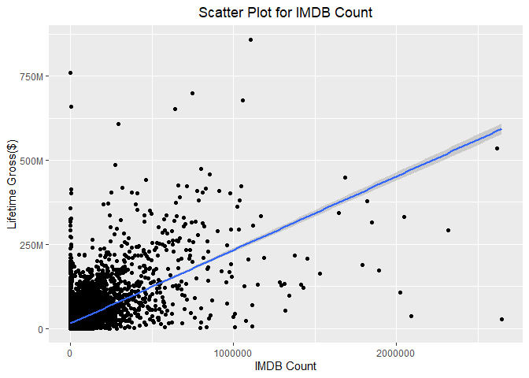

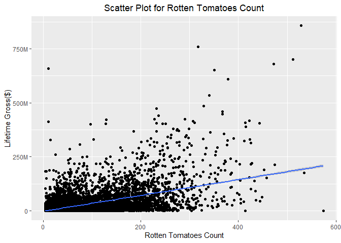

```
##
##  Pearson's product-moment correlation
##
## data:  movie$imdbC and movie$LifetimeGross
## t = 67.631, df = 7979, p-value < 0.00000000000000022
## alternative hypothesis: true correlation is not equal to 0
## 95 percent confidence interval:
##  0.5895002 0.6173961
## sample estimates:
##       cor
## 0.6036329
```

```
##
##  Pearson's product-moment correlation
##
## data:  movie$rottentmtC and movie$LifetimeGross
## t = 52.538, df = 7979, p-value < 0.00000000000000022
## alternative hypothesis: true correlation is not equal to 0
## 95 percent confidence interval:
##  0.4904925 0.5230979
## sample estimates:
##       cor
## 0.5069765
```

### 4.3 SMART Question: Does **content rating** affect to box office performance?

[output not shown]

[output cut: 7025 more lines]

[output not shown]

# 5. Linear Regression Model

First, following table is the correlation for all numerical variables.

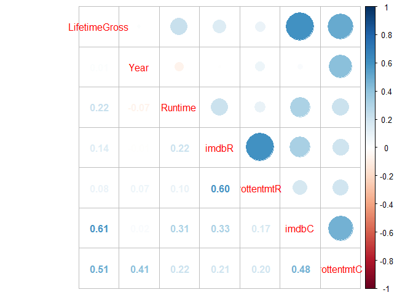

### 5.1 Model Fitting: Goals and Overview

We fit several models with the goal of finding which combination of predictors worked best for predicting domestic lifetime gross. Out initial strategy was to use a correlation plot and forward selection to find the best combination of numerical predictors. Then, due to our finding in the EDA process, we added content rating to the best model to see if that improved model performance. We found that the best model included number of IMDb ratings, number of Rotten Tomatos ratings, and Content Rating as predictors for domestic lifetime gross. It is worth noting that during the EDA process, we did discover that several model conditions were not being met in particular the normality assumption. However, because our somple size is so large, we still proceeded to fit these linear models.

### 5.2 Model Results Summary and Interpretations

Model 1: Lifetime Gross = bo + b1xIMDbC H0: b1 = 0 (IMDb count has no significant effect on Lifetime gross) Ha: b1 != 0 (There is some effect)

```
##
## Call:
## lm(formula = LifetimeGross ~ imdbC, data = movie)
##
## Residuals:
##        Min         1Q     Median         3Q        Max
## -564528474  -15385317  -13664810    3651938  745675151
##
## Coefficients:
##                Estimate  Std. Error t value            Pr(>|t|)
## (Intercept) 14827449.56   532885.86   27.82 <0.0000000000000002 ***
## imdbC            218.47        3.23   67.63 <0.0000000000000002 ***
## ---
## Signif. codes:  0 '***' 0.001 '**' 0.01 '*' 0.05 '.' 0.1 ' ' 1
##
## Residual standard error: 44290000 on 7979 degrees of freedom
## Multiple R-squared:  0.3644, Adjusted R-squared:  0.3643
## F-statistic:  4574 on 1 and 7979 DF,  p-value: < 0.00000000000000022
```

The t-statistic for the coefficient on `imdbC` is 67.63, which gives a p-value of approximately 0. Therefore we can reject the null hypothesis and conclude that there is strong evidence that `imdbC` has a positive relationship with lifetime gross.

Model 2: Lifetime Gross = bo + b1xIMDbCount + b2xRTCount H0: b2 = 0 (Rotten Tomato count has no significant effect on Lifetime gross) Ha: b2 != 0 (There is some effect)

```
##
## Call:
## lm(formula = LifetimeGross ~ imdbC + rottentmtC, data = movie)
##
## Residuals:
##        Min         1Q     Median         3Q        Max
## -436805477  -15675707   -5049702    5567385  694319662
##
## Coefficients:
##               Estimate Std. Error t value            Pr(>|t|)
## (Intercept) 808562.975 691573.112   1.169               0.242
## imdbC          169.651      3.478  48.780 <0.0000000000000002 ***
## rottentmtC  206231.855   6940.276  29.715 <0.0000000000000002 ***
## ---
## Signif. codes:  0 '***' 0.001 '**' 0.01 '*' 0.05 '.' 0.1 ' ' 1
##
## Residual standard error: 42020000 on 7978 degrees of freedom
## Multiple R-squared:  0.4277, Adjusted R-squared:  0.4276
## F-statistic:  2981 on 2 and 7978 DF,  p-value: < 0.00000000000000022
```

Model 3: Lifetime Gross = bo + b1xIMDbCount + b2xRTCount + b3xruntime H0: b3 = 0 (Runtime has no significant effect on Lifetime gross) Ha: b3 != 0 (There is some effect)

```
##
## Call:
## lm(formula = LifetimeGross ~ imdbC + rottentmtC + Runtime, data = movie)
##
## Residuals:
##        Min         1Q     Median         3Q        Max
## -435621020  -15587477   -4972775    5499731  692415264
##
## Coefficients:
##                 Estimate   Std. Error t value            Pr(>|t|)
## (Intercept) -3663691.882  2539790.943  -1.443              0.1492
## imdbC            168.501        3.607  46.719 <0.0000000000000002 ***
## rottentmtC    203958.914     7053.370  28.917 <0.0000000000000002 ***
## Runtime        45788.395    24969.255   1.834              0.0667 .
## ---
## Signif. codes:  0 '***' 0.001 '**' 0.01 '*' 0.05 '.' 0.1 ' ' 1
##
## Residual standard error: 42090000 on 7853 degrees of freedom
##   (결측으로 인하여 124개의 관측치가 삭제되었습니다.)
## Multiple R-squared:   0.43,  Adjusted R-squared:  0.4298
## F-statistic:  1975 on 3 and 7853 DF,  p-value: < 0.00000000000000022
```

The t-statistic for runtime is 1.834, which gives a p-value of 0.0667. There is no evidence that there is a statistically significant relationship between runtime and domestic lifetime gross. For this reason, we rejected this predictor from our model.

Model 4: Lifetime Gross = bo + b1xIMDbCount + b2xRTCount + *b3*XcontentRating H0: all b3i = 0, where i represents the levels of content rating (content rating has no significant effect on Lifetime gross) Ha: some b3i != 0 (Some level of content rating has an effect)

```
##
## Call:
## lm(formula = LifetimeGross ~ imdbC + rottentmtC + contentR, data = movie)
##
## Residuals:
##        Min         1Q     Median         3Q        Max
## -419877844  -17567782   -3041806    6889637  687586154
##
## Coefficients:
##                    Estimate    Std. Error t value             Pr(>|t|)
## (Intercept)    30822318.738   3110075.725   9.910 < 0.0000000000000002 ***
## imdbC               166.758         3.358  49.653 < 0.0000000000000002 ***
## rottentmtC       202463.035      6921.854  29.250 < 0.0000000000000002 ***
## contentRPG    -11572488.263   3312339.841  -3.494             0.000479 ***
## contentRPG-13 -22085465.507   3221954.475  -6.855     0.00000000000768 ***
## contentRR     -39004660.757   3157172.620 -12.354 < 0.0000000000000002 ***
## contentRNC17  -46028807.431  10041800.580  -4.584     0.00000463729293 ***
## contentRNR    -35212182.380   3354651.650 -10.497 < 0.0000000000000002 ***
## ---
## Signif. codes:  0 '***' 0.001 '**' 0.01 '*' 0.05 '.' 0.1 ' ' 1
##
## Residual standard error: 40540000 on 7973 degrees of freedom
## Multiple R-squared:  0.4678, Adjusted R-squared:  0.4673
## F-statistic:  1001 on 7 and 7973 DF,  p-value: < 0.00000000000000022
```

The coefficients for all ratings have p-values of approximately 0. For this reason, we can reject our null hypothesis and say that at least one coefficient for content rating is not zero. There is strong evidence that content rating has a statisitically significant relationship with domestic lifetime gross.

ANOVA: Models 2 & 4

```
## Analysis of Variance Table
##
## Model 1: LifetimeGross ~ imdbC + rottentmtC + contentR
## Model 2: LifetimeGross ~ imdbC + rottentmtC
##   Res.Df                  RSS Df           Sum of Sq      F
## 1   7973 13102905643649916928
## 2   7978 14089519729364713472 -5 -986614085714796544 120.07
##                  Pr(>F)
## 1
## 2 < 0.00000000000000022 ***
## ---
## Signif. codes:  0 '***' 0.001 '**' 0.01 '*' 0.05 '.' 0.1 ' ' 1
```

# 6. Conclusion

### 6.1 Limitations

The main goal when analyze data and drawing conclusions is to have a sample representative of the given population. We should be able to infer the population based on our analysis of the sample. Although we used data from two very popular rating sites, we must acknowledge that there are many more rating sites that people use to rate movies. The issue in using these various sites was that the data was either unavailable without a fee or was very incomplete, which could skew our data. We thought it would be best to use the most complete data from two popular rating websites. In doing so, we also acknowledge that this may not be the most representative sample. Although, with close to 8,000 observations, this is still a robust dataset.

# 7. Bibliography

Scott, G. Determinants of box office performance: Return of the regressions. Retrieved October 28, 2022, from https://scholarworks.uni.edu/cgi/viewcontent.cgi?article=1143&context=mtie